# Risk Factor Analysis

## Outcome Variable

**Outcome Variable:** co_occurence

## Predictor Variables

**Intervention Variable:** pers_wasted06

**Adjustment Set:**

- sex
- arm
- brthmon
- single
- hhwealth_quart
- W_mage
- W_mhtcm
- W_meducyrs
- W_feducyrs
- delta_brthmon
- delta_single
- delta_hhwealth_quart
- delta_W_mage
- delta_W_mhtcm
- delta_W_meducyrs
- delta_W_feducyrs

## Stratifying Variables

The analysis was stratified on these variable(s):

- studyid
- country

## Data Summary

| studyid | country | pers_wasted06 | co_occurence | n_cell | n | outcome_variable |
| --- | --- | --- | --- | --- | --- | --- |
| CMC-V-BCS-2002 | INDIA | 0 | 0 | 308 | 366 | co_occurence |
| CMC-V-BCS-2002 | INDIA | 0 | 1 | 7 | 366 | co_occurence |
| CMC-V-BCS-2002 | INDIA | 1 | 0 | 36 | 366 | co_occurence |
| CMC-V-BCS-2002 | INDIA | 1 | 1 | 15 | 366 | co_occurence |
| CMIN | BANGLADESH | 0 | 0 | 205 | 237 | co_occurence |
| CMIN | BANGLADESH | 0 | 1 | 23 | 237 | co_occurence |
| CMIN | BANGLADESH | 1 | 0 | 6 | 237 | co_occurence |
| CMIN | BANGLADESH | 1 | 1 | 3 | 237 | co_occurence |
| COHORTS | GUATEMALA | 0 | 0 | 706 | 774 | co_occurence |
| COHORTS | GUATEMALA | 0 | 1 | 31 | 774 | co_occurence |
| COHORTS | GUATEMALA | 1 | 0 | 30 | 774 | co_occurence |
| COHORTS | GUATEMALA | 1 | 1 | 7 | 774 | co_occurence |
| COHORTS | PHILIPPINES | 0 | 0 | 2191 | 2487 | co_occurence |
| COHORTS | PHILIPPINES | 0 | 1 | 154 | 2487 | co_occurence |
| COHORTS | PHILIPPINES | 1 | 0 | 109 | 2487 | co_occurence |
| COHORTS | PHILIPPINES | 1 | 1 | 33 | 2487 | co_occurence |
| CONTENT | PERU | 0 | 0 | 200 | 200 | co_occurence |
| CONTENT | PERU | 0 | 1 | 0 | 200 | co_occurence |
| CONTENT | PERU | 1 | 0 | 0 | 200 | co_occurence |
| CONTENT | PERU | 1 | 1 | 0 | 200 | co_occurence |
| EE | PAKISTAN | 0 | 0 | 258 | 346 | co_occurence |
| EE | PAKISTAN | 0 | 1 | 63 | 346 | co_occurence |
| EE | PAKISTAN | 1 | 0 | 14 | 346 | co_occurence |
| EE | PAKISTAN | 1 | 1 | 11 | 346 | co_occurence |
| GMS-Nepal | NEPAL | 0 | 0 | 440 | 550 | co_occurence |
| GMS-Nepal | NEPAL | 0 | 1 | 47 | 550 | co_occurence |
| GMS-Nepal | NEPAL | 1 | 0 | 50 | 550 | co_occurence |
| GMS-Nepal | NEPAL | 1 | 1 | 13 | 550 | co_occurence |
| IRC | INDIA | 0 | 0 | 325 | 405 | co_occurence |
| IRC | INDIA | 0 | 1 | 22 | 405 | co_occurence |

[output cut: 78 more lines]

The following strata were considered:

- studyid: CMC-V-BCS-2002, country: INDIA
- studyid: CMIN, country: BANGLADESH
- studyid: COHORTS, country: GUATEMALA
- studyid: COHORTS, country: PHILIPPINES
- studyid: CONTENT, country: PERU
- studyid: EE, country: PAKISTAN
- studyid: GMS-Nepal, country: NEPAL
- studyid: IRC, country: INDIA
- studyid: JiVitA-4, country: BANGLADESH
- studyid: Keneba, country: GAMBIA
- studyid: LCNI-5, country: MALAWI
- studyid: MAL-ED, country: BANGLADESH
- studyid: MAL-ED, country: BRAZIL
- studyid: MAL-ED, country: INDIA
- studyid: MAL-ED, country: NEPAL
- studyid: MAL-ED, country: PERU
- studyid: MAL-ED, country: SOUTH AFRICA
- studyid: MAL-ED, country: TANZANIA, UNITED REPUBLIC OF
- studyid: NIH-Birth, country: BANGLADESH
- studyid: NIH-Crypto, country: BANGLADESH
- studyid: PROBIT, country: BELARUS
- studyid: PROVIDE, country: BANGLADESH
- studyid: ResPak, country: PAKISTAN
- studyid: SAS-CompFeed, country: INDIA
- studyid: SAS-FoodSuppl, country: INDIA
- studyid: TanzaniaChild2, country: TANZANIA, UNITED REPUBLIC OF
- studyid: ZVITAMBO, country: ZIMBABWE

### Dropped Strata

Some strata were dropped due to rare outcomes:

- studyid: CMIN, country: BANGLADESH
- studyid: CONTENT, country: PERU
- studyid: IRC, country: INDIA
- studyid: LCNI-5, country: MALAWI
- studyid: MAL-ED, country: BANGLADESH
- studyid: MAL-ED, country: BRAZIL
- studyid: MAL-ED, country: INDIA
- studyid: MAL-ED, country: NEPAL
- studyid: MAL-ED, country: PERU
- studyid: MAL-ED, country: SOUTH AFRICA
- studyid: MAL-ED, country: TANZANIA, UNITED REPUBLIC OF
- studyid: PROBIT, country: BELARUS
- studyid: PROVIDE, country: BANGLADESH
- studyid: ResPak, country: PAKISTAN
- studyid: TanzaniaChild2, country: TANZANIA, UNITED REPUBLIC OF

## Methods Detail

We’re interested in the causal parameters $E[Y_a]$ for all values of $a \in \mathcal{A}$. These parameters represent the mean outcome if, possibly contrary to fact, we intervened to set all units to have $A=a$. Under the randomization and positivity assumptions, these are identified by the statistical parameters $\psi_a=E_W[E_{Y|A,W}(Y|A=a,W)]$. In addition, we’re interested in the mean of $Y$, $E[Y]$ under no intervention (the observed mean). We will estimate these parameters by using SuperLearner to fit the relevant likelihood factors – $E_{Y|A,W}(Y|A=a,W)$ and $p(A=a|W)$, and then updating our likelihood fit using a joint TMLE.

For unadjusted analyses ($W=\{\}$), initial likelihoods were estimated using Lrnr_glm to estimate the simple $E(Y|A)$ and Lrnr_mean to estimate $p(A)$. For adjusted analyses, a small library containing Lrnr_glmnet, Lrnr_xgboost, and Lrnr_mean was used.

Having estimated these parameters, we will then use the delta method to estimate relative risks and attributable risks relative to a prespecified baseline level of $A$.

[output not shown]

[output not shown]

# Results Detail

## Results Plots

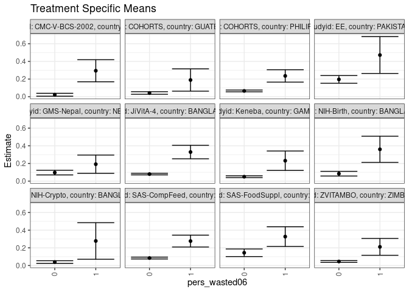

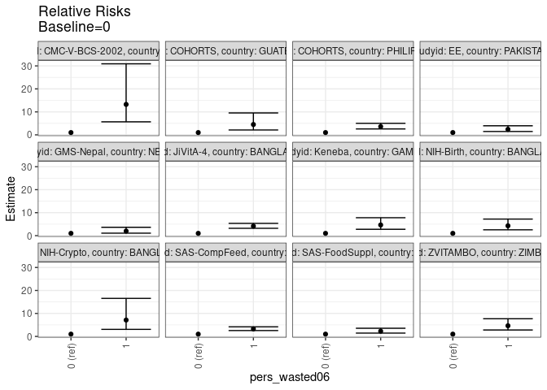

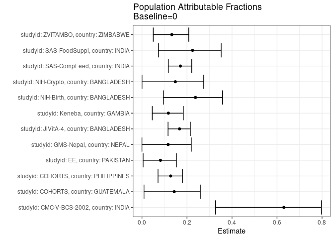

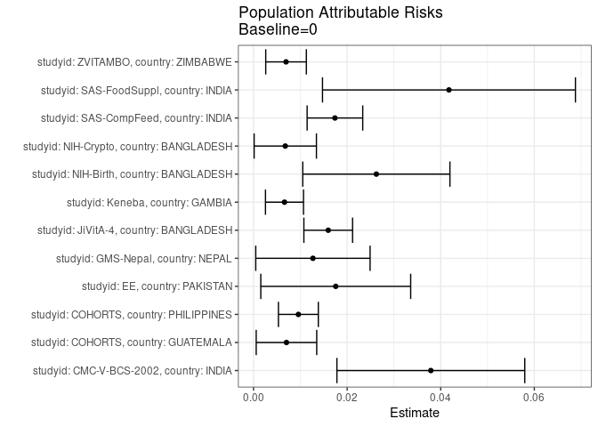

## Results Table

### Parameter: TSM

| studyid | country | intervention_level | baseline_level | estimate | ci_lower | ci_upper |
| --- | --- | --- | --- | --- | --- | --- |
| CMC-V-BCS-2002 | INDIA | 0 | NA | 0.0222222 | 0.0059217 | 0.0385227 |
| CMC-V-BCS-2002 | INDIA | 1 | NA | 0.2941176 | 0.1688947 | 0.4193406 |
| COHORTS | GUATEMALA | 0 | NA | 0.0420624 | 0.0275610 | 0.0565638 |
| COHORTS | GUATEMALA | 1 | NA | 0.1891892 | 0.0629088 | 0.3154696 |
| COHORTS | PHILIPPINES | 0 | NA | 0.0656105 | 0.0555890 | 0.0756321 |
| COHORTS | PHILIPPINES | 1 | NA | 0.2355402 | 0.1654783 | 0.3056022 |
| EE | PAKISTAN | 0 | NA | 0.1963102 | 0.1527554 | 0.2398649 |
| EE | PAKISTAN | 1 | NA | 0.4718659 | 0.2631896 | 0.6805422 |
| GMS-Nepal | NEPAL | 0 | NA | 0.0964036 | 0.0701280 | 0.1226793 |
| GMS-Nepal | NEPAL | 1 | NA | 0.1914267 | 0.0879415 | 0.2949119 |
| JiVitA-4 | BANGLADESH | 0 | NA | 0.0796886 | 0.0705561 | 0.0888211 |
| JiVitA-4 | BANGLADESH | 1 | NA | 0.3289940 | 0.2525618 | 0.4054263 |
| Keneba | GAMBIA | 0 | NA | 0.0497268 | 0.0394305 | 0.0600230 |
| Keneba | GAMBIA | 1 | NA | 0.2309413 | 0.1211173 | 0.3407653 |
| NIH-Birth | BANGLADESH | 0 | NA | 0.0841496 | 0.0575227 | 0.1107765 |
| NIH-Birth | BANGLADESH | 1 | NA | 0.3600944 | 0.2116967 | 0.5084922 |
| NIH-Crypto | BANGLADESH | 0 | NA | 0.0389610 | 0.0236683 | 0.0542538 |
| NIH-Crypto | BANGLADESH | 1 | NA | 0.2777778 | 0.0706975 | 0.4848581 |
| SAS-CompFeed | INDIA | 0 | NA | 0.0845203 | 0.0741696 | 0.0948710 |
| SAS-CompFeed | INDIA | 1 | NA | 0.2764714 | 0.2092520 | 0.3436908 |
| SAS-FoodSuppl | INDIA | 0 | NA | 0.1439972 | 0.1011403 | 0.1868542 |
| SAS-FoodSuppl | INDIA | 1 | NA | 0.3270264 | 0.2152180 | 0.4388349 |
| ZVITAMBO | ZIMBABWE | 0 | NA | 0.0454369 | 0.0352529 | 0.0556209 |
| ZVITAMBO | ZIMBABWE | 1 | NA | 0.2109315 | 0.1156322 | 0.3062309 |

### Parameter: E(Y)

| studyid | country | intervention_level | baseline_level | estimate | ci_lower | ci_upper |
| --- | --- | --- | --- | --- | --- | --- |
| CMC-V-BCS-2002 | INDIA | NA | NA | 0.0601093 | 0.0357249 | 0.0844936 |
| COHORTS | GUATEMALA | NA | NA | 0.0490956 | 0.0338639 | 0.0643273 |
| COHORTS | PHILIPPINES | NA | NA | 0.0751910 | 0.0648251 | 0.0855569 |
| EE | PAKISTAN | NA | NA | 0.2138728 | 0.1706052 | 0.2571404 |
| GMS-Nepal | NEPAL | NA | NA | 0.1090909 | 0.0830130 | 0.1351688 |
| JiVitA-4 | BANGLADESH | NA | NA | 0.0956483 | 0.0855904 | 0.1057063 |
| Keneba | GAMBIA | NA | NA | 0.0563380 | 0.0456085 | 0.0670675 |
| NIH-Birth | BANGLADESH | NA | NA | 0.1103896 | 0.0817833 | 0.1389959 |
| NIH-Crypto | BANGLADESH | NA | NA | 0.0457413 | 0.0294659 | 0.0620168 |
| SAS-CompFeed | INDIA | NA | NA | 0.1019108 | 0.0902026 | 0.1136190 |
| SAS-FoodSuppl | INDIA | NA | NA | 0.1857585 | 0.1432798 | 0.2282372 |
| ZVITAMBO | ZIMBABWE | NA | NA | 0.0523810 | 0.0417242 | 0.0630377 |

### Parameter: RR

| studyid | country | intervention_level | baseline_level | estimate | ci_lower | ci_upper |
| --- | --- | --- | --- | --- | --- | --- |
| CMC-V-BCS-2002 | INDIA | 0 | 0 | 1.000000 | 1.000000 | 1.000000 |
| CMC-V-BCS-2002 | INDIA | 1 | 0 | 13.235294 | 5.667550 | 30.908064 |
| COHORTS | GUATEMALA | 0 | 0 | 1.000000 | 1.000000 | 1.000000 |
| COHORTS | GUATEMALA | 1 | 0 | 4.497820 | 2.121945 | 9.533891 |
| COHORTS | PHILIPPINES | 0 | 0 | 1.000000 | 1.000000 | 1.000000 |
| COHORTS | PHILIPPINES | 1 | 0 | 3.589976 | 2.570849 | 5.013102 |
| EE | PAKISTAN | 0 | 0 | 1.000000 | 1.000000 | 1.000000 |
| EE | PAKISTAN | 1 | 0 | 2.403675 | 1.464114 | 3.946179 |
| GMS-Nepal | NEPAL | 0 | 0 | 1.000000 | 1.000000 | 1.000000 |
| GMS-Nepal | NEPAL | 1 | 0 | 1.985679 | 1.084128 | 3.636952 |
| JiVitA-4 | BANGLADESH | 0 | 0 | 1.000000 | 1.000000 | 1.000000 |
| JiVitA-4 | BANGLADESH | 1 | 0 | 4.128495 | 3.194550 | 5.335485 |
| Keneba | GAMBIA | 0 | 0 | 1.000000 | 1.000000 | 1.000000 |
| Keneba | GAMBIA | 1 | 0 | 4.644204 | 2.765540 | 7.799065 |
| NIH-Birth | BANGLADESH | 0 | 0 | 1.000000 | 1.000000 | 1.000000 |
| NIH-Birth | BANGLADESH | 1 | 0 | 4.279217 | 2.543885 | 7.198320 |
| NIH-Crypto | BANGLADESH | 0 | 0 | 1.000000 | 1.000000 | 1.000000 |
| NIH-Crypto | BANGLADESH | 1 | 0 | 7.129630 | 3.070223 | 16.556328 |
| SAS-CompFeed | INDIA | 0 | 0 | 1.000000 | 1.000000 | 1.000000 |
| SAS-CompFeed | INDIA | 1 | 0 | 3.271065 | 2.554500 | 4.188635 |
| SAS-FoodSuppl | INDIA | 0 | 0 | 1.000000 | 1.000000 | 1.000000 |
| SAS-FoodSuppl | INDIA | 1 | 0 | 2.271060 | 1.450098 | 3.556804 |
| ZVITAMBO | ZIMBABWE | 0 | 0 | 1.000000 | 1.000000 | 1.000000 |
| ZVITAMBO | ZIMBABWE | 1 | 0 | 4.642299 | 2.803201 | 7.687973 |

### Parameter: PAR

| studyid | country | intervention_level | baseline_level | estimate | ci_lower | ci_upper |
| --- | --- | --- | --- | --- | --- | --- |
| CMC-V-BCS-2002 | INDIA | 0 | NA | 0.0378871 | 0.0178137 | 0.0579604 |
| COHORTS | GUATEMALA | 0 | NA | 0.0070332 | 0.0005665 | 0.0134999 |
| COHORTS | PHILIPPINES | 0 | NA | 0.0095805 | 0.0053166 | 0.0138443 |
| EE | PAKISTAN | 0 | NA | 0.0175627 | 0.0015481 | 0.0335772 |
| GMS-Nepal | NEPAL | 0 | NA | 0.0126873 | 0.0004713 | 0.0249032 |
| JiVitA-4 | BANGLADESH | 0 | NA | 0.0159597 | 0.0107549 | 0.0211646 |
| Keneba | GAMBIA | 0 | NA | 0.0066113 | 0.0025477 | 0.0106748 |
| NIH-Birth | BANGLADESH | 0 | NA | 0.0262400 | 0.0105144 | 0.0419656 |
| NIH-Crypto | BANGLADESH | 0 | NA | 0.0067803 | 0.0001243 | 0.0134362 |
| SAS-CompFeed | INDIA | 0 | NA | 0.0173905 | 0.0114494 | 0.0233316 |
| SAS-FoodSuppl | INDIA | 0 | NA | 0.0417613 | 0.0147350 | 0.0687876 |
| ZVITAMBO | ZIMBABWE | 0 | NA | 0.0069441 | 0.0026021 | 0.0112861 |

### Parameter: PAF

| studyid | country | intervention_level | baseline_level | estimate | ci_lower | ci_upper |
| --- | --- | --- | --- | --- | --- | --- |
| CMC-V-BCS-2002 | INDIA | 0 | NA | 0.6303030 | 0.3262436 | 0.7971435 |
| COHORTS | GUATEMALA | 0 | NA | 0.1432550 | 0.0090294 | 0.2593000 |
| COHORTS | PHILIPPINES | 0 | NA | 0.1274150 | 0.0713134 | 0.1801276 |
| EE | PAKISTAN | 0 | NA | 0.0821173 | 0.0051172 | 0.1531579 |
| GMS-Nepal | NEPAL | 0 | NA | 0.1162999 | -0.0000917 | 0.2191457 |
| JiVitA-4 | BANGLADESH | 0 | NA | 0.1668584 | 0.1158501 | 0.2149239 |
| Keneba | GAMBIA | 0 | NA | 0.1173497 | 0.0456314 | 0.1836786 |
| NIH-Birth | BANGLADESH | 0 | NA | 0.2377036 | 0.0949084 | 0.3579702 |
| NIH-Crypto | BANGLADESH | 0 | NA | 0.1482311 | 0.0002406 | 0.2743151 |
| SAS-CompFeed | INDIA | 0 | NA | 0.1706445 | 0.1169088 | 0.2211105 |
| SAS-FoodSuppl | INDIA | 0 | NA | 0.2248149 | 0.0728263 | 0.3518885 |
| ZVITAMBO | ZIMBABWE | 0 | NA | 0.1325688 | 0.0500631 | 0.2079085 |